[figure not shown]

```python
%matplotlib inline
from IPython.core.display import Image, display
from __future__ import print_function
display(Image('C://Users//Dar1//Documents//she_codes//python//she codes logo big python.png',
              width=600, height=200))
```

# Pandas Ex.9: Solution

Author: Dar Lador

> **References:**
> 1. Python for Data Analysis By Wes McKinney.
> 2. tip.csv file obtained from the book’s GitHub repository.

To illustrate some more advanced aggregation features, we’ll use a less trivial dataset, a dataset on restaurant tipping. It was originally found in Bryant & Smith’s 1995 text on business statistics (and found [here](https://drive.google.com/open?id=0B9crmgoWupXkUElwVGoyS0VuX1E)).

#### 1. After loading it with read_csv, add a tipping percentage column `tip_pct`.

**1.1.** Load `tip.csv` and assign in to the variable `tips`

```python
import os
import pandas as pd
pd.set_option('display.notebook_repr_html', False) #ignore this statement

tips = pd.read_csv(os.path.join("python-for-data-analytics-master//ch08",'tips.csv'))
```

**1.2.** Add a column name `tip_pct`, and get tip precentage of final bill by dividing the column `tip` by the column `total_bill`.

```python
tips['tip_pct'] = tips['tip'] / tips['total_bill']
tips[:3]
```

```
   total_bill   tip     sex smoker  day    time  size   tip_pct
0       16.99  1.01  Female     No  Sun  Dinner     2  0.059447
1       10.34  1.66    Male     No  Sun  Dinner     3  0.160542
2       21.01  3.50    Male     No  Sun  Dinner     3  0.166587
```

#### 2. What is the average tip % given by smoker / non-smoker women / men? (hint: use `agg` function)

**2.1.** Group the `tips` by `sex` and `smoker` (assign it to `grouped` variable).

```python
grouped = tips.groupby(['sex', 'smoker'])
```

**2.2.** Assign `grouped_pct` variable to the column `tip_pct` in `grouped`

```python
grouped_pct = grouped['tip_pct']
```

**2.3.** Use `agg` with the desired function `mean` to get the final answer (more information can be found [here](http://pandas.pydata.org/pandas-docs/stable/groupby.html#applying-multiple-functions-at-once)).

```python
grouped_pct.agg('mean')
```

```
sex     smoker
Female  No        0.156921
        Yes       0.182150
Male    No        0.160669
        Yes       0.152771
Name: tip_pct, dtype: float64
```

#### 3. Use the same `agg` function to compute both the mean and the std. What is the format (type) of the output?

**3.1.** Pass a list of functions or function names (i.e. `'mean'`, `'std'`) instead

```python
grouped_pct.agg(['mean', 'std'])
```

```
                   mean       std
sex    smoker
Female No      0.156921  0.036421
       Yes     0.182150  0.071595
Male   No      0.160669  0.041849
       Yes     0.152771  0.090588
```

**3.2.** Print the type of the output

```python
print(type(grouped_pct.agg(['mean', 'std'])))
```

```
<class 'pandas.core.frame.DataFrame'>
```

With a DataFrame, you have more options as you can specify a list of functions to apply to all of the columns or different functions per column.

#### 4. Compute the same three statistics `'count'`, `'mean'` and `'max'` for the `tip_pct` and `total_bill` columns. How many columns you'll get?

**4.1.** Let `function` to be a list with the strings `'count'`, `'mean'` and `'max'`.

```python
functions = ['count', 'mean', 'max']
```

**4.2.** Use `agg(functions`) on the columns `tip_pct` and `total_bill` in `grouped` (assign it to `result` variable)

```python
result = grouped['tip_pct', 'total_bill'].agg(functions)
result
```

```
              tip_pct                     total_bill
                count      mean       max      count       mean    max
sex    smoker
Female No          54  0.156921  0.252672         54  18.105185  35.83
       Yes         33  0.182150  0.416667         33  17.977879  44.30
Male   No          97  0.160669  0.291990         97  19.791237  48.33
       Yes         60  0.152771  0.710345         60  22.284500  50.81
```

**4.3.** The resulting DataFrame has hierarchical columns. However, the number of columns is niether 8 nor 2. Compute the length of `result` columns.

```python
len(result.columns)
```

```
6
```

#### 5. Compute the statistics `'min'`,`'max'`, `'mean'` and `'std'` for the `tip_pct` column and `'sum'` for the `'size'` column.

**5.1.** Pass a dict to agg that contains a mapping of column names to any of the function specifications listed above.

```python
grouped.agg({'tip_pct' : ['min', 'max', 'mean', 'std'], 'size' : 'sum'})
```

```
              size   tip_pct
               sum       min       max      mean       std
sex    smoker
Female No      140  0.056797  0.252672  0.156921  0.036421
       Yes      74  0.056433  0.416667  0.182150  0.071595
Male   No      263  0.071804  0.291990  0.160669  0.041849
       Yes     150  0.035638  0.710345  0.152771  0.090588
```

**Note:** A DataFrame will have hierarchical columns only if multiple functions are applied to at least one column.

#### 6. Select the top 5 generous smokers and non-smpkers

**6.1.** Build a function `top` which attributes `df`, `n` (for the top n) and `column`. In this function use `sort_values` to sort the values in the column specified.

```python
def top(df, n=5, column='tip_pct'):
    return df.sort_values(by=column)[-n:]
```

**Note:** Do not appy this function on the whole data frame (e.i. `top(tips, n=5)`) as the output will be the top 5 regardless of smokers and non-smokers.

**6.2.** Group the `tips` dataframe by `'smoker` and use `apply(top)` to apply this function.

```python
tips.groupby('smoker').apply(top)
```

```
            total_bill   tip     sex smoker   day    time  size   tip_pct
smoker
No     88        24.71  5.85    Male     No  Thur   Lunch     2  0.236746
       185       20.69  5.00    Male     No   Sun  Dinner     5  0.241663
       51        10.29  2.60  Female     No   Sun  Dinner     2  0.252672
       149        7.51  2.00    Male     No  Thur   Lunch     2  0.266312
       232       11.61  3.39    Male     No   Sat  Dinner     2  0.291990
Yes    109       14.31  4.00  Female    Yes   Sat  Dinner     2  0.279525
       183       23.17  6.50    Male    Yes   Sun  Dinner     4  0.280535
       67         3.07  1.00  Female    Yes   Sat  Dinner     1  0.325733
       178        9.60  4.00  Female    Yes   Sun  Dinner     2  0.416667
       172        7.25  5.15    Male    Yes   Sun  Dinner     2  0.710345
```

#### 7. Show the count, mean, std, min, max, 25%, 50% and 75% percentiles of the `tip_pct` of smokers and non-smokers

**7.1.** Group the `tips` dataframe by `'smoker` and use `describe` method on `tip_pct` column.

**Tip:** `my_result.unstack('smoker')` will look better

```python
result = tips.groupby('smoker')['tip_pct'].describe()
result.unstack('smoker')
```

```
smoker          No        Yes
count   151.000000  93.000000
mean      0.159328   0.163196
std       0.039910   0.085119
min       0.056797   0.035638
25%       0.136906   0.106771
50%       0.155625   0.153846
75%       0.185014   0.195059
max       0.291990   0.710345
```

### Pivot table

> A [pivot table](http://pandas.pydata.org/pandas-docs/stable/generated/pandas.pivot_table.html) is a data summarization tool frequently found in spreadsheet programs and other data analysis software. It aggregates a table of data by one or more keys, arranging the data in a rectangle with some of the group keys along the rows and some along the columns. Pivot tables in Python with pandas are made possible using the `groupby` facility. DataFrame has a pivot_table method, and additionally there is a top-level `pandas.pivot_table` function. In addition to providing a convenience interface to `groupby`, `pivot_table` also can add partial totals, also known as *margins*.

#### 8. Use `pivot_table` function on the rows `sex` and `smoker`.

**8.1.** You can do it by writing something like `df.pivot_table(index=[...])`

```python
tips.pivot_table(index=['sex', 'smoker'])
```

```
                   size       tip   tip_pct  total_bill
sex    smoker
Female No      2.592593  2.773519  0.156921   18.105185
       Yes     2.242424  2.931515  0.182150   17.977879
Male   No      2.711340  3.113402  0.160669   19.791237
       Yes     2.500000  3.051167  0.152771   22.284500
```

#### 9. Use `pivot_table` to show the `tip_pct` when the columns are the days, the index are sex and smoker or non-smoker and the values are the number of values in each day.

**9.1.** Use something like df.pivot_table(on_column, index=[...], cols='day', aggfunc=len, margins=True)

```python
tips.pivot_table('tip_pct', index=['sex', 'smoker'], columns='day', aggfunc=len, margins=True)
```

```
day             Fri   Sat   Sun  Thur    All
sex    smoker
Female No       2.0  13.0  14.0  25.0   54.0
       Yes      7.0  15.0   4.0   7.0   33.0
Male   No       2.0  32.0  43.0  20.0   97.0
       Yes      8.0  27.0  15.0  10.0   60.0
All            19.0  87.0  76.0  62.0  244.0
```

### Visualization of data frames

Suppose we wanted to make a stacked bar plot showing the percentage of data points for each party size on each day.

#### 10. Use [pd.crosstab](http://pandas.pydata.org/pandas-docs/version/0.17.0/generated/pandas.crosstab.html) where the days are the indexes and the size are in the columns. How many 1 and 6 person party are there?

**10.1.** `party_counts` variable should be equalt to something like `pd.crosstab(tips[wanted_index], tips[wanted_columns])'

```python
party_counts = pd.crosstab(tips.day, tips['size'])
party_counts
```

```
size  1   2   3   4  5  6
day
Fri   1  16   1   1  0  0
Sat   2  53  18  13  1  0
Sun   0  39  15  18  3  1
Thur  1  48   4   5  1  3
```

#### 11. Filter out 1 and 6 person parties as there are not many of them

Hint: Use something like `my_new_df = df.ix[rows, cols]`

```python
party_counts = party_counts.ix[:, 2:5]
```

#### 12. Normalize the new df so that each row sums to 1 and make a stacked bar plot

**12.1.** It's a little bit tricky. Use `my_new_df.div(...)` and add `party_counts.sum(1).astype(float)` and `axis=0` within the `div`'s parenthesis

```python
party_pcts = party_counts.div(party_counts.sum(1).astype(float), axis=0)
party_pcts
```

```
size         2         3         4         5
day
Fri   0.888889  0.055556  0.055556  0.000000
Sat   0.623529  0.211765  0.152941  0.011765
Sun   0.520000  0.200000  0.240000  0.040000
Thur  0.827586  0.068966  0.086207  0.017241
```

**12.2.** Use `df.plot` function, with `kind=bar` and `stacked=True`

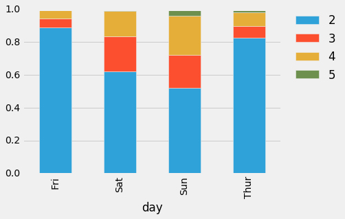

```python
import matplotlib.pyplot as plt
from matplotlib import style
style.use('fivethirtyeight')

party_pcts.plot(kind='bar', stacked=True)
plt.legend(loc='lower right', bbox_to_anchor=(1.25, 0.5))
```

#### 13. Make a histogram (with 50 bins) of tip percentages of the total bill

**13.1.** Just use `my_df[my_column].hist(bins=50)`

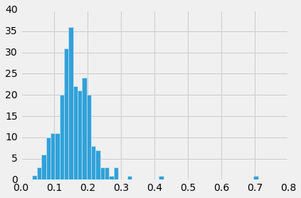

```python
tips['tip_pct'].hist(bins=50)
```

#### 14. Use `plot` function with `kind='kde'` to make a density plot (of the tips %) using the standard mixture-of-normals KDE

**14.1.** Just use something like `my_df[my_col].plot(kind='kde')`

> A density plot is formed by computing an estimate of a continuous probability distribution that might have generated the observed data. A usual procedure is to approximate this distribution as a mixture of kernels, that is, simpler distributions like the normal (Gaussian) distribution. Thus, density plots are also known as KDE (kernel density estimate) plots.

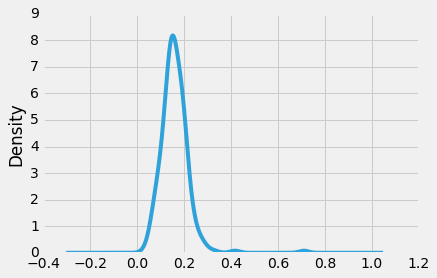

```python
tips['tip_pct'].plot(kind='kde')
```